# P5: Identify Fraud from Enron Email

### Worksheet

I used this as a sort of ongoing analysis and testing ground for the data and classifiers. Most of my work is here, and the poi_id.py submission contains the final - and clean - code to actually complete the project.

```python
import sys
import pickle
sys.path.append("../tools/")
%matplotlib inline
import matplotlib.pyplot as plt
import seaborn as sns

from feature_format import featureFormat, targetFeatureSplit
```

```python
### Task 1: Select what features you'll use.
### features_list is a list of strings, each of which is a feature name.
### The first feature must be "poi".
features_list = ['poi',
    'salary',
    'bonus',
    'long_term_incentive',
    'deferred_income',
    'deferral_payments',
    'loan_advances',
    'other',
    'expenses',
    'director_fees',
    'total_payments',

    'exercised_stock_options',
    'restricted_stock',
    'restricted_stock_deferred',
    'total_stock_value',

    'from_this_person_to_poi',
    'to_messages',
    'from_poi_to_this_person',
    'from_messages',
    'shared_receipt_with_poi',

    # Email related fractional features
    'to_poi_fraction',
    'from_poi_fraction',

    # Payment related fractional features
    'salary_fraction',
    'bonus_fraction',
    'long_term_incentive_fraction',
    'deferred_income_fraction',
    'deferral_payments_fraction',
    'loan_advances_fraction',
    'other_fraction',
    'expenses_fraction',
    'director_fees_fraction',

    # Stock related fractional features
    'exercised_stock_options_fraction',
    'restricted_stock_fraction',
    'restricted_stock_deferred_fraction']
```

```python
### Load the dictionary containing the dataset
with open("final_project_dataset.pkl", "r") as data_file:
    data_dict = pickle.load(data_file)
```

```python
data_dict.keys()
```

```
['METTS MARK',
 'BAXTER JOHN C',
 'ELLIOTT STEVEN',
 'CORDES WILLIAM R',
 'HANNON KEVIN P',
 'MORDAUNT KRISTINA M',
 'MEYER ROCKFORD G',
 'MCMAHON JEFFREY',
 'HORTON STANLEY C',
 'PIPER GREGORY F',
 'HUMPHREY GENE E',
 'UMANOFF ADAM S',
 'BLACHMAN JEREMY M',
 'SUNDE MARTIN',
 'GIBBS DANA R',
 'LOWRY CHARLES P',
 'COLWELL WESLEY',
 'MULLER MARK S',
 'JACKSON CHARLENE R',
 'WESTFAHL RICHARD K',
 'WALTERS GARETH W',
 'WALLS JR ROBERT H',
 'KITCHEN LOUISE',
 'CHAN RONNIE',
 'BELFER ROBERT',
 'SHANKMAN JEFFREY A',
 'WODRASKA JOHN',
 'BERGSIEKER RICHARD P',
 'URQUHART JOHN A',
 'BIBI PHILIPPE A',
 'RIEKER PAULA H',
 'WHALEY DAVID A',
 'BECK SALLY W',
 'HAUG DAVID L',
 'ECHOLS JOHN B',
 'MENDELSOHN JOHN',
 'HICKERSON GARY J',
 'CLINE KENNETH W',
 'LEWIS RICHARD',
 'HAYES ROBERT E',
```

[output cut: 91 more lines]

```
 'BAY FRANKLIN R',
 'HAYSLETT RODERICK J',
 'FUGH JOHN L',
 'FALLON JAMES B',
 'KOENIG MARK E',
 'SAVAGE FRANK',
 'IZZO LAWRENCE L',
 'TILNEY ELIZABETH A',
 'MARTIN AMANDA K',
 'BUY RICHARD B',
 'GRAMM WENDY L',
 'CAUSEY RICHARD A',
 'TAYLOR MITCHELL S',
 'DONAHUE JR JEFFREY M',
 'GLISAN JR BEN F']
```

```python
### Task 2: Remove outliers
# On first pass, I'm going to remove 'TOTAL' and 'THE TRAVEL AGENCY IN THE PARK', since they're clearly not people
del data_dict["TOTAL"]
del data_dict["THE TRAVEL AGENCY IN THE PARK"]
```

```python
### Task 3: Create new feature(s)

# Create features list for easy creation of new features
payment_features = ['salary', 'bonus', 'long_term_incentive', 'deferred_income',
    'deferral_payments', 'loan_advances', 'other', 'expenses', 'director_fees']

stock_features = ['exercised_stock_options', 'restricted_stock',
    'restricted_stock_deferred']

for p in data_dict:
    # Create fractional value of emails to POIs
    if data_dict[p]['from_this_person_to_poi'] == "NaN" or \
    data_dict[p]['from_messages'] == "NaN":
        data_dict[p]['to_poi_fraction'] = "NaN"
    else:
        data_dict[p]['to_poi_fraction'] = \
        data_dict[p]['from_this_person_to_poi'] / \
        float(data_dict[p]['from_messages'])

    # Create fractional value of emails from POIs
    if data_dict[p]['from_poi_to_this_person'] == "NaN" or \
    data_dict[p]['to_messages'] == "NaN":
        data_dict[p]['from_poi_fraction'] = "NaN"
    else:
        data_dict[p]['from_poi_fraction'] = \
        data_dict[p]['from_poi_to_this_person'] / \
        float(data_dict[p]['to_messages'])

    for pay in payment_features:
        if data_dict[p][pay] == "NaN" or data_dict[p]['total_payments'] == "NaN":
            data_dict[p][pay + "_fraction"] = "NaN"
        else:
            data_dict[p][pay + "_fraction"] = float(data_dict[p][pay]) / \
            data_dict[p]['total_payments']

    for stock in stock_features:
        if data_dict[p][stock] == "NaN" or \
        data_dict[p]['total_stock_value'] == "NaN":
            data_dict[p][stock + "_fraction"] = "NaN"
        else:
            data_dict[p][stock + "_fraction"] = float(data_dict[p][stock]) / \
            data_dict[p]['total_stock_value']
```

```python
# Feature exploration, creating dicts with total NaN values for features and persons
# The goal is to try to find features or persons that lack data, so I can remove them as a potential
# outlier (persons) or not use that feature (feature selection).

feature_list = {feature:{'NaN':0} for feature in features_list}
person_list = {person:{'NaN':0} for person in data_dict}
total_features = len(features_list)
```

```python
# increment NaN counters for the respective dicts
for person in data_dict:
    for feature in features_list:
        if data_dict[person][feature] == 'NaN':
            feature_list[feature]['NaN'] += 1
            person_list[person]['NaN'] += 1
```

```python
# find the ratio of NaN to actual values
for feature in feature_list:
    feature_list[feature]['ratio'] = feature_list[feature]['NaN']/float(len(data_dict))

for person in person_list:
    person_list[person]['ratio'] = person_list[person]['NaN']/float(total_features)
```

```python
# For both persons and features, create a list sorted by most features missing
print total_features
sorted_person_list = [(k, person_list[k]) for k in sorted(person_list, key=person_list.__getitem__, reverse=True)]
sorted_person_list
```

```
34
```

```
[('LOCKHART EUGENE E', {'NaN': 33, 'ratio': 0.9705882352941176}),
 ('WODRASKA JOHN', {'NaN': 30, 'ratio': 0.8823529411764706}),
 ('WHALEY DAVID A', {'NaN': 30, 'ratio': 0.8823529411764706}),
 ('WROBEL BRUCE', {'NaN': 30, 'ratio': 0.8823529411764706}),
 ('SCRIMSHAW MATTHEW', {'NaN': 30, 'ratio': 0.8823529411764706}),
 ('GRAMM WENDY L', {'NaN': 30, 'ratio': 0.8823529411764706}),
 ('CHAN RONNIE', {'NaN': 29, 'ratio': 0.8529411764705882}),
 ('CLINE KENNETH W', {'NaN': 28, 'ratio': 0.8235294117647058}),
 ('WAKEHAM JOHN', {'NaN': 28, 'ratio': 0.8235294117647058}),
 ('GILLIS JOHN', {'NaN': 28, 'ratio': 0.8235294117647058}),
 ('CHRISTODOULOU DIOMEDES', {'NaN': 28, 'ratio': 0.8235294117647058}),
 ('SAVAGE FRANK', {'NaN': 28, 'ratio': 0.8235294117647058}),
 ('YEAP SOON', {'NaN': 27, 'ratio': 0.7941176470588235}),
 ('FUGH JOHN L', {'NaN': 27, 'ratio': 0.7941176470588235}),
 ('LOWRY CHARLES P', {'NaN': 26, 'ratio': 0.7647058823529411}),
 ('URQUHART JOHN A', {'NaN': 26, 'ratio': 0.7647058823529411}),
 ('MENDELSOHN JOHN', {'NaN': 26, 'ratio': 0.7647058823529411}),
 ('MEYER JEROME J', {'NaN': 26, 'ratio': 0.7647058823529411}),
 ('GATHMANN WILLIAM D', {'NaN': 26, 'ratio': 0.7647058823529411}),
 ('PEREIRA PAULO V. FERRAZ', {'NaN': 26, 'ratio': 0.7647058823529411}),
 ('BLAKE JR. NORMAN P', {'NaN': 26, 'ratio': 0.7647058823529411}),
 ('WINOKUR JR. HERBERT S', {'NaN': 26, 'ratio': 0.7647058823529411}),
 ('NOLES JAMES L', {'NaN': 25, 'ratio': 0.7352941176470589}),
 ('WALTERS GARETH W', {'NaN': 25, 'ratio': 0.7352941176470589}),
 ('DUNCAN JOHN H', {'NaN': 25, 'ratio': 0.7352941176470589}),
 ('LEMAISTRE CHARLES', {'NaN': 25, 'ratio': 0.7352941176470589}),
 ('BADUM JAMES P', {'NaN': 25, 'ratio': 0.7352941176470589}),
 ('PRENTICE JAMES', {'NaN': 25, 'ratio': 0.7352941176470589}),
 ('POWERS WILLIAM', {'NaN': 24, 'ratio': 0.7058823529411765}),
 ('GRAY RODNEY', {'NaN': 24, 'ratio': 0.7058823529411765}),
 ('BELFER ROBERT', {'NaN': 23, 'ratio': 0.6764705882352942}),
 ('LEWIS RICHARD', {'NaN': 23, 'ratio': 0.6764705882352942}),
 ('BERBERIAN DAVID', {'NaN': 23, 'ratio': 0.6764705882352942}),
 ('PIRO JIM', {'NaN': 23, 'ratio': 0.6764705882352942}),
 ('BROWN MICHAEL', {'NaN': 23, 'ratio': 0.6764705882352942}),
 ('HIRKO JOSEPH', {'NaN': 23, 'ratio': 0.6764705882352942}),
 ('HAYSLETT RODERICK J', {'NaN': 23, 'ratio': 0.6764705882352942}),
 ('CORDES WILLIAM R', {'NaN': 21, 'ratio': 0.6176470588235294}),
 ('MORDAUNT KRISTINA M', {'NaN': 21, 'ratio': 0.6176470588235294}),
 ('KISHKILL JOSEPH G', {'NaN': 21, 'ratio': 0.6176470588235294}),
```

[output cut: 89 more lines]

```
 ('HANNON KEVIN P', {'NaN': 8, 'ratio': 0.23529411764705882}),
 ('MULLER MARK S', {'NaN': 8, 'ratio': 0.23529411764705882}),
 ('RIEKER PAULA H', {'NaN': 8, 'ratio': 0.23529411764705882}),
 ('OLSON CINDY K', {'NaN': 8, 'ratio': 0.23529411764705882}),
 ('BELDEN TIMOTHY N', {'NaN': 8, 'ratio': 0.23529411764705882}),
 ('RICE KENNETH D', {'NaN': 8, 'ratio': 0.23529411764705882}),
 ('WASAFF GEORGE', {'NaN': 8, 'ratio': 0.23529411764705882}),
 ('SHARP VICTORIA T', {'NaN': 8, 'ratio': 0.23529411764705882}),
 ('BUY RICHARD B', {'NaN': 8, 'ratio': 0.23529411764705882}),
 ('PIPER GREGORY F', {'NaN': 6, 'ratio': 0.17647058823529413}),
 ('DERRICK JR. JAMES V', {'NaN': 6, 'ratio': 0.17647058823529413}),
 ('HAEDICKE MARK E', {'NaN': 4, 'ratio': 0.11764705882352941}),
 ('LAY KENNETH L', {'NaN': 4, 'ratio': 0.11764705882352941}),
 ('ALLEN PHILLIP K', {'NaN': 4, 'ratio': 0.11764705882352941}),
 ('FREVERT MARK A', {'NaN': 4, 'ratio': 0.11764705882352941})]
```

```python
# Because he has no data
del data_dict['LOCKHART EUGENE E']
```

```python
print len(data_dict)
sorted_feature_list = [(k, feature_list[k]) for k in sorted(feature_list, key=feature_list.__getitem__, reverse=True)]
sorted_feature_list
```

```
143
```

```
[('loan_advances_fraction', {'NaN': 141, 'ratio': 0.9791666666666666}),
 ('loan_advances', {'NaN': 141, 'ratio': 0.9791666666666666}),
 ('director_fees_fraction', {'NaN': 130, 'ratio': 0.9027777777777778}),
 ('restricted_stock_deferred_fraction',
  {'NaN': 130, 'ratio': 0.9027777777777778}),
 ('director_fees', {'NaN': 128, 'ratio': 0.8888888888888888}),
 ('restricted_stock_deferred', {'NaN': 127, 'ratio': 0.8819444444444444}),
 ('deferral_payments', {'NaN': 106, 'ratio': 0.7361111111111112}),
 ('deferral_payments_fraction', {'NaN': 106, 'ratio': 0.7361111111111112}),
 ('deferred_income_fraction', {'NaN': 98, 'ratio': 0.6805555555555556}),
 ('deferred_income', {'NaN': 96, 'ratio': 0.6666666666666666}),
 ('long_term_incentive', {'NaN': 79, 'ratio': 0.5486111111111112}),
 ('long_term_incentive_fraction', {'NaN': 79, 'ratio': 0.5486111111111112}),
 ('bonus_fraction', {'NaN': 63, 'ratio': 0.4375}),
 ('bonus', {'NaN': 63, 'ratio': 0.4375}),
 ('to_messages', {'NaN': 58, 'ratio': 0.4027777777777778}),
 ('to_poi_fraction', {'NaN': 58, 'ratio': 0.4027777777777778}),
 ('from_poi_to_this_person', {'NaN': 58, 'ratio': 0.4027777777777778}),
 ('shared_receipt_with_poi', {'NaN': 58, 'ratio': 0.4027777777777778}),
 ('from_messages', {'NaN': 58, 'ratio': 0.4027777777777778}),
 ('from_poi_fraction', {'NaN': 58, 'ratio': 0.4027777777777778}),
 ('from_this_person_to_poi', {'NaN': 58, 'ratio': 0.4027777777777778}),
 ('other_fraction', {'NaN': 53, 'ratio': 0.3680555555555556}),
 ('other', {'NaN': 53, 'ratio': 0.3680555555555556}),
 ('expenses', {'NaN': 50, 'ratio': 0.3472222222222222}),
 ('salary_fraction', {'NaN': 50, 'ratio': 0.3472222222222222}),
 ('salary', {'NaN': 50, 'ratio': 0.3472222222222222}),
 ('expenses_fraction', {'NaN': 50, 'ratio': 0.3472222222222222}),
 ('exercised_stock_options_fraction',
  {'NaN': 44, 'ratio': 0.3055555555555556}),
 ('exercised_stock_options', {'NaN': 43, 'ratio': 0.2986111111111111}),
 ('restricted_stock_fraction', {'NaN': 38, 'ratio': 0.2638888888888889}),
 ('restricted_stock', {'NaN': 35, 'ratio': 0.24305555555555555}),
 ('total_payments', {'NaN': 21, 'ratio': 0.14583333333333334}),
 ('total_stock_value', {'NaN': 19, 'ratio': 0.13194444444444445}),
 ('poi', {'NaN': 0, 'ratio': 0.0})]
```

Based on this, I think I can safely remove 'loan advances', 'director_fees', 'restricted_stock_deferred', and their associated fraction features from features_list for having no data for more than 80% of total entries. This is a first attempt at feature selection, based on simple EDA.

```python
# First elimination:
# Removed 'loan advances', 'director_fees', 'restricted_stock_deferred',
# and their associated fraction features for having no data for more than 80%
# of total entries
features_list = ['poi',
    'salary',
    'bonus',
    'long_term_incentive',
    'deferred_income',
    'deferral_payments',
    'other',
    'expenses',
    'total_payments',

    'exercised_stock_options',
    'restricted_stock',
    'total_stock_value',

    'from_this_person_to_poi',
    'to_messages',
    'from_poi_to_this_person',
    'from_messages',
    'shared_receipt_with_poi',]

fractional_features_list = [
    # Email related fractional features
    'to_poi_fraction',
    'from_poi_fraction',

    # Payment related fractional features
    'salary_fraction',
    'bonus_fraction',
    'long_term_incentive_fraction',
    'deferred_income_fraction',
    'deferral_payments_fraction',
    'other_fraction',
    'expenses_fraction',

    # Stock related fractional features
    'exercised_stock_options_fraction',
    'restricted_stock_fraction']
```

```python
# Evaluate features list by POI characteristics
poi_feature_list = {feature:{'poi':0, 'n_poi':0, 'other': 0, 'sum':0} for feature in features_list}

for person in data_dict:
    if data_dict[person]['poi']:
        for feature in poi_feature_list:
            if data_dict[person][feature] != "NaN":
                poi_feature_list[feature]['poi'] += 1
            else:
                poi_feature_list[feature]['other'] += 1
    else:
        for feature in poi_feature_list:
            if data_dict[person][feature] != "NaN":
                poi_feature_list[feature]['n_poi'] += 1
            else:
                poi_feature_list[feature]['other'] += 1

for f in poi_feature_list:
    for sub_f in poi_feature_list[f]:
        if sub_f != 'sum':
            poi_feature_list[f]['sum'] += poi_feature_list[f][sub_f]

# Calculate the percentages of each
non_poi_total =  len(data_dict) - 18.0
poi_total = 18.0

# Make new dictionary for percentages
perc_poi_feature_list = {feature:{'poi':0, 'n_poi':0, 'other':0} for feature in features_list}

for f in perc_poi_feature_list:
    perc_poi_feature_list[f]['poi'] = round(poi_feature_list[f]['poi'] / poi_total, 3)
    perc_poi_feature_list[f]['n_poi'] = round(poi_feature_list[f]['n_poi'] / non_poi_total, 3)
    perc_poi_feature_list[f]['other'] = round(poi_feature_list[f]['other'] / non_poi_total, 3)
```

```python
poi_feature_list
```

```
{'bonus': {'n_poi': 65, 'other': 62, 'poi': 16, 'sum': 143},
 'deferral_payments': {'n_poi': 33, 'other': 105, 'poi': 5, 'sum': 143},
 'deferred_income': {'n_poi': 37, 'other': 95, 'poi': 11, 'sum': 143},
 'exercised_stock_options': {'n_poi': 89, 'other': 42, 'poi': 12, 'sum': 143},
 'expenses': {'n_poi': 76, 'other': 49, 'poi': 18, 'sum': 143},
 'from_messages': {'n_poi': 72, 'other': 57, 'poi': 14, 'sum': 143},
 'from_poi_to_this_person': {'n_poi': 72, 'other': 57, 'poi': 14, 'sum': 143},
 'from_this_person_to_poi': {'n_poi': 72, 'other': 57, 'poi': 14, 'sum': 143},
 'long_term_incentive': {'n_poi': 53, 'other': 78, 'poi': 12, 'sum': 143},
 'other': {'n_poi': 73, 'other': 52, 'poi': 18, 'sum': 143},
 'poi': {'n_poi': 125, 'other': 0, 'poi': 18, 'sum': 143},
 'restricted_stock': {'n_poi': 92, 'other': 34, 'poi': 17, 'sum': 143},
 'salary': {'n_poi': 77, 'other': 49, 'poi': 17, 'sum': 143},
 'shared_receipt_with_poi': {'n_poi': 72, 'other': 57, 'poi': 14, 'sum': 143},
 'to_messages': {'n_poi': 72, 'other': 57, 'poi': 14, 'sum': 143},
 'total_payments': {'n_poi': 105, 'other': 20, 'poi': 18, 'sum': 143},
 'total_stock_value': {'n_poi': 107, 'other': 18, 'poi': 18, 'sum': 143}}
```

```python
perc_poi_feature_list
```

```
{'bonus': {'n_poi': 0.52, 'other': 0.496, 'poi': 0.889},
 'deferral_payments': {'n_poi': 0.264, 'other': 0.84, 'poi': 0.278},
 'deferred_income': {'n_poi': 0.296, 'other': 0.76, 'poi': 0.611},
 'exercised_stock_options': {'n_poi': 0.712, 'other': 0.336, 'poi': 0.667},
 'expenses': {'n_poi': 0.608, 'other': 0.392, 'poi': 1.0},
 'from_messages': {'n_poi': 0.576, 'other': 0.456, 'poi': 0.778},
 'from_poi_to_this_person': {'n_poi': 0.576, 'other': 0.456, 'poi': 0.778},
 'from_this_person_to_poi': {'n_poi': 0.576, 'other': 0.456, 'poi': 0.778},
 'long_term_incentive': {'n_poi': 0.424, 'other': 0.624, 'poi': 0.667},
 'other': {'n_poi': 0.584, 'other': 0.416, 'poi': 1.0},
 'poi': {'n_poi': 1.0, 'other': 0.0, 'poi': 1.0},
 'restricted_stock': {'n_poi': 0.736, 'other': 0.272, 'poi': 0.944},
 'salary': {'n_poi': 0.616, 'other': 0.392, 'poi': 0.944},
 'shared_receipt_with_poi': {'n_poi': 0.576, 'other': 0.456, 'poi': 0.778},
 'to_messages': {'n_poi': 0.576, 'other': 0.456, 'poi': 0.778},
 'total_payments': {'n_poi': 0.84, 'other': 0.16, 'poi': 1.0},
 'total_stock_value': {'n_poi': 0.856, 'other': 0.144, 'poi': 1.0}}
```

Interestingly enough, the only features that have values for all POIs are expenses, other, poi (for obvious reasons), total_payments, and total_stock_value. I think a small exception can be made for restricted_stock and salary, since only 1 POI is missing these features respectively.

```python
### Store to my_dataset for easy export below.
my_dataset = data_dict
```

```python
len(my_dataset)
```

```
143
```

```python
### Extract features and labels from dataset for local testing
data = featureFormat(my_dataset, features_list, sort_keys = True)
labels, features = targetFeatureSplit(data)
```

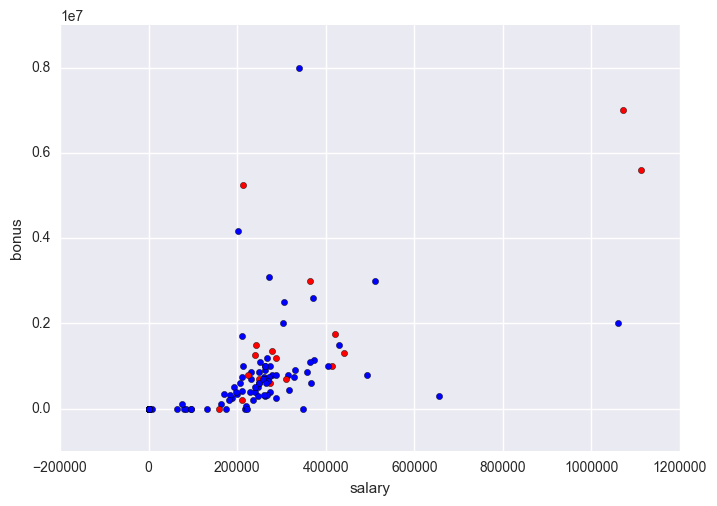

```python
# This is a test of visualization

for point in data:
    poi = point[0]
    salary = point[1]
    bonus = point[2]
    if poi >= .9:
        plt.scatter( salary, bonus, c="r" )
    else:
        plt.scatter( salary, bonus)

plt.xlabel("salary")
plt.ylabel("bonus")
plt.show()
```

```python
# Moving on, I'm going to experiment with feature selection
# First building the the simplified training and test split
from sklearn.cross_validation import train_test_split
features_train, features_test, labels_train, labels_test = train_test_split(features, labels, test_size=0.2, random_state=42)
```

```python
# Next, I'm going to set up a simple NaiveBayes classifier and perform feature selection
# using SelectKBest over a range of values to determine the best classifiers
from sklearn.feature_selection import SelectKBest, f_classif
from sklearn.naive_bayes import GaussianNB
from sklearn.pipeline import make_pipeline, Pipeline

# Create ANOVA filter
anova_filter = SelectKBest(f_classif, k=5)

# Naive Bayes classifier
clf = GaussianNB()

anova_nb = make_pipeline(anova_filter, clf)
anova_filter.fit(features_train, labels_train)

print anova_filter.scores_
print anova_filter.pvalues_
```

```
[ 18.6742056   29.63748334  11.16548585  10.14635349   0.094709
   3.74758069   4.84683601   8.58074937  15.5840072    9.20180973
  15.71769956   4.29884361   2.61734982   5.27320436   0.07113568
  10.55982643]
[  3.37252508e-05   3.11086032e-07   1.13312542e-03   1.87320664e-03
   7.58845442e-01   5.54044175e-02   2.97473759e-02   4.11734282e-03
   1.38191160e-04   3.00541158e-03   1.29886329e-04   4.04319743e-02
   1.08513800e-01   2.35161714e-02   7.90180796e-01   1.52626408e-03]
```

```python
# Try to determine which features are being scored
feature_scores = zip(features_list, anova_filter.scores_, anova_filter.pvalues_)
sorted(feature_scores, key=lambda score: score[1], reverse=True)
```

```
[('salary', 29.637483342825991, 3.1108603200930706e-07),
 ('poi', 18.674205599965617, 3.3725250835901779e-05),
 ('restricted_stock', 15.717699564931332, 0.0001298863285464782),
 ('total_payments', 15.584007198962444, 0.00013819116044938053),
 ('bonus', 11.165485853767775, 0.0011331254165007831),
 ('from_messages', 10.559826426637898, 0.001526264078135481),
 ('long_term_incentive', 10.146353491703897, 0.0018732066423035063),
 ('exercised_stock_options', 9.2018097295558974, 0.0030054115762484044),
 ('expenses', 8.5807493683478953, 0.0041173428171727674),
 ('to_messages', 5.2732043586790045, 0.023516171356882967),
 ('other', 4.8468360056263613, 0.029747375898322773),
 ('total_stock_value', 4.2988436103134529, 0.040431974275502193),
 ('deferral_payments', 3.7475806934062388, 0.055404417508767831),
 ('from_this_person_to_poi', 2.6173498152262775, 0.10851380016382584),
 ('deferred_income', 0.094709003418012097, 0.75884544224391326),
 ('from_poi_to_this_person', 0.071135677630847091, 0.79018079647658435)]
```

It worked!! Now I'm going to repeat the process, but with the full list of features, including fractional ones, to find out the f_classif scores for each.

```python
#Create full features list
full_features_list = ['poi',
    'salary',
    'bonus',
    'long_term_incentive',
    'deferred_income',
    'deferral_payments',
    'loan_advances',
    'other',
    'expenses',
    'director_fees',
    'total_payments',

    'exercised_stock_options',
    'restricted_stock',
    'restricted_stock_deferred',
    'total_stock_value',

    'from_this_person_to_poi',
    'to_messages',
    'from_poi_to_this_person',
    'from_messages',
    'shared_receipt_with_poi',

    # Email related fractional features
    'to_poi_fraction',
    'from_poi_fraction',

    # Payment related fractional features
    'salary_fraction',
    'bonus_fraction',
    'long_term_incentive_fraction',
    'deferred_income_fraction',
    'deferral_payments_fraction',
    'loan_advances_fraction',
    'other_fraction',
    'expenses_fraction',
    'director_fees_fraction',

    # Stock related fractional features
    'exercised_stock_options_fraction',
    'restricted_stock_fraction',
    'restricted_stock_deferred_fraction']
```

```python
# Extract features and labels from dataset for local testing on full features list
data = featureFormat(my_dataset, full_features_list, sort_keys = True)
labels_full, features_full = targetFeatureSplit(data)
```

```python
# Create new anova filter then find the feature scores
anova_filter_full = SelectKBest(f_classif, k=5)

anova_filter_full.fit(features_full, labels_full)

# Try to determine which features are being scored
feature_scores = zip(full_features_list, anova_filter_full.scores_, anova_filter_full.pvalues_)
sorted(feature_scores, key=lambda score: score[1], reverse=True)
```

```
[('total_payments', 24.815079733218194, 1.8182048777865317e-06),
 ('restricted_stock_deferred', 24.182898678566879, 2.4043152760436886e-06),
 ('salary', 20.792252047181535, 1.10129873239521e-05),
 ('salary_fraction', 20.715596247559954, 1.1403848516905529e-05),
 ('poi', 18.289684043404513, 3.4782737683651706e-05),
 ('shared_receipt_with_poi', 16.409712548035792, 8.3889533567042162e-05),
 ('bonus_fraction', 13.850868417167648, 0.00028512514965536027),
 ('long_term_incentive', 11.458476579280369, 0.00092203670846723062),
 ('bonus', 9.9221860131898225, 0.0019941812453537077),
 ('exercised_stock_options', 9.2128106219771002, 0.002862802957909168),
 ('director_fees', 8.7727777300916756, 0.0035893261725153044),
 ('from_messages', 8.589420731682381, 0.0039458026165322567),
 ('deferral_payments', 7.1840556582887247, 0.0082318509068451656),
 ('other', 6.0941733106389453, 0.014758199965371975),
 ('deferral_payments_fraction', 5.3463405918745792, 0.02221386974369996),
 ('to_messages', 5.2434497133749582, 0.023513867086669717),
 ('loan_advances', 4.1874775069953749, 0.042581747012345836),
 ('to_poi_fraction', 3.1280917481567192, 0.079116105663795441),
 ('from_poi_fraction', 2.687417590844055, 0.10337293194951264),
 ('total_stock_value', 2.3826121082276739, 0.12493365956927895),
 ('expenses', 2.1263278020077054, 0.14701111317392224),
 ('from_this_person_to_poi', 1.6463411294420076, 0.20156265029435688),
 ('deferred_income_fraction', 1.3604336117316531, 0.24543136205493971),
 ('exercised_stock_options_fraction', 1.0901571696328429, 0.29822315230244967),
 ('loan_advances_fraction', 1.0684733217820632, 0.30306019680461482),
 ('restricted_stock_fraction', 0.76477268331683201, 0.383326169421491),
 ('deferred_income', 0.22461127473600989, 0.63628164745867344),
 ('expenses_fraction', 0.20806402247992767, 0.6489908434639271),
 ('from_poi_to_this_person', 0.16970094762175533, 0.68100330042070167),
 ('long_term_incentive_fraction', 0.15002858163937585, 0.69909208283267188),
 ('restricted_stock', 0.065499652909942141, 0.79837865656298534),
 ('director_fees_fraction', 0.04211676849806735, 0.8376933284866297),
 ('other_fraction', 0.017509612462176017, 0.89491675396671311)]
```

These results don't make much sense to me, since some features that had very little data, such as restricted_stock_deferred and director_fees, scored very well, and some features that scored well without the fractional values added, such as restricted_stock, scored terribly. Most of the fractional features scored terribly low, so I think I am going to move forward by only using the normal features_list, with the addition of bonus_fraction. I think the scaled values make it a better predictor overall. I'm going to swap bonus and bonus_fraction, so that I don't have two closely correlated values in the feature selection list.

```python
# Entire process repeated again
final_features_list = ['poi',
    'salary',
    'bonus_fraction', #subbed for bonus
    'long_term_incentive',
    'deferred_income',
    'deferral_payments',
    'other',
    'expenses',
    'total_payments',

    'exercised_stock_options',
    'restricted_stock',
    'total_stock_value',

    'from_this_person_to_poi',
    'to_messages',
    'from_poi_to_this_person',
    'from_messages',
    'shared_receipt_with_poi']

# Extract features and labels from dataset for local testing on full features list
data = featureFormat(my_dataset, final_features_list, sort_keys = True)
labels_final, features_final = targetFeatureSplit(data)

# Create new anova filter then find the feature scores
anova_filter_final = SelectKBest(f_classif, k=5)

anova_filter_final.fit(features_final, labels_final)

# Try to determine which features are being scored
feature_scores = zip(final_features_list, anova_filter_final.scores_, anova_filter_final.pvalues_)
sorted(feature_scores, key=lambda score: score[1], reverse=True)
```

```
[('total_payments', 24.815079733218194, 1.8182048777865317e-06),
 ('restricted_stock', 24.182898678566879, 2.4043152760436886e-06),
 ('salary', 20.715596247559954, 1.1403848516905529e-05),
 ('poi', 18.289684043404513, 3.4782737683651706e-05),
 ('long_term_incentive', 11.458476579280369, 0.00092203670846723062),
 ('bonus_fraction', 9.9221860131898225, 0.0019941812453537077),
 ('exercised_stock_options', 9.2128106219771002, 0.002862802957909168),
 ('expenses', 8.7727777300916756, 0.0035893261725153044),
 ('from_messages', 8.589420731682381, 0.0039458026165322567),
 ('other', 6.0941733106389453, 0.014758199965371975),
 ('to_messages', 5.2434497133749582, 0.023513867086669717),
 ('deferral_payments', 4.1874775069953749, 0.042581747012345836),
 ('total_stock_value', 2.3826121082276739, 0.12493365956927895),
 ('from_this_person_to_poi', 1.6463411294420076, 0.20156265029435688),
 ('deferred_income', 0.22461127473600989, 0.63628164745867344),
 ('from_poi_to_this_person', 0.16970094762175533, 0.68100330042070167)]
```

This list makes the most sense to me right now. I am now going to use a Naive Bayes classifier in a GridSearchCV pipeline to determine the optimal SelectKBest features for this data_set

```python
# set up the pipes and pipeline
# Anova filter
anova_filter = SelectKBest(f_classif)
parameters = {'selectkbest__k':[2,4,5,6,8,10]}

# Naive Bayes classifier
gauss_nb = GaussianNB()

# Pipeline
anova_nb = make_pipeline(anova_filter, gauss_nb)

anova_nb.steps
```

```
[('selectkbest',
  SelectKBest(k=10, score_func=<function f_classif at 0x000000000BDE80B8>)),
 ('gaussiannb', GaussianNB())]
```

```python
# import Grid Search
from sklearn.grid_search import GridSearchCV

#GridSearchCV
clf = GridSearchCV(anova_nb, parameters)
```

```python
# Create training and testing data
features_train, features_test, labels_train, labels_test = train_test_split(features_final, labels_final, test_size=0.2, random_state=42)
```

```python
clf.fit(features_train, labels_train)
clf.grid_scores_
```

```
[mean: 0.84211, std: 0.01811, params: {'selectkbest__k': 2},
 mean: 0.81579, std: 0.02408, params: {'selectkbest__k': 4},
 mean: 0.81579, std: 0.02408, params: {'selectkbest__k': 5},
 mean: 0.80702, std: 0.00892, params: {'selectkbest__k': 6},
 mean: 0.80702, std: 0.01632, params: {'selectkbest__k': 8},
 mean: 0.81579, std: 0.00396, params: {'selectkbest__k': 10}]
```

OK, so 2 features has the best score, 4 and 5 are similar, and 10 has the lowest standard deviation. So, in lieu of trimming down the feature list, I think I am just going to keep the SelectKBest feature selection for the pipeline moving forward, with values of 2, 4, 5, and 10. Keeping this step will help to programmatically find the best features for each of the learning algorithms going forward.

```python
# Creating of mulitple simple algorithms for quick analysis of best performance
# Using Naive Bayes, Decision Trees, SVM, Random Forest, and AdaBoost
# Imports
from sklearn.tree import DecisionTreeClassifier
from sklearn import svm
from sklearn.ensemble import RandomForestClassifier
from sklearn.ensemble import AdaBoostClassifier
from sklearn.metrics import classification_report, precision_score, recall_score, f1_score


# Naive Bayes classifier
gaussNB_clf = GaussianNB()

# Decision Tree classifier
tree_clf = DecisionTreeClassifier(min_samples_split=10)

# Support Vector Machines
lnr_svm_clf = svm.SVC(kernel="linear", C=100.)
rbf_svm_clf = svm.SVC(kernel="rbf", C=100.)

# Random Forest
ranfor_clf = RandomForestClassifier()

# Adaboost
adab_clf = AdaBoostClassifier()
```

```python
# Create pipeline then run test of resulting algos
anova_filter = SelectKBest(f_classif, k=10)
algo_list = [gaussNB_clf, tree_clf, lnr_svm_clf, rbf_svm_clf, ranfor_clf, adab_clf]

# Create pipe function and run fit on algorithms with 10 SelectKBest
def pipe_and_report(algo):
    pipe = make_pipeline(anova_filter, algo)
    pipe.fit(features_train, labels_train)
    pred = pipe.predict(features_test)
    clf_report = classification_report(labels_test, pred)
    print clf_report

pipe_and_report(gaussNB_clf)
```

```
             precision    recall  f1-score   support

        0.0       0.96      0.93      0.94        27
        1.0       0.33      0.50      0.40         2

avg / total       0.92      0.90      0.91        29
```

```python
pipe_and_report(tree_clf)
```

```
             precision    recall  f1-score   support

        0.0       0.92      0.85      0.88        27
        1.0       0.00      0.00      0.00         2

avg / total       0.86      0.79      0.82        29
```

```python
# I tried these, but my computer basically died, so I may come back some other time

#pipe_and_report(lnr_svm_clf)
#pipe_and_report(rbf_svm_clf)
```

```python
pipe_and_report(ranfor_clf)
```

```
             precision    recall  f1-score   support

        0.0       0.93      0.96      0.95        27
        1.0       0.00      0.00      0.00         2

avg / total       0.86      0.90      0.88        29
```

```python
pipe_and_report(adab_clf)
```

```
             precision    recall  f1-score   support

        0.0       0.92      0.89      0.91        27
        1.0       0.00      0.00      0.00         2

avg / total       0.86      0.83      0.84        29
```

```python
# Setup random forest pipe
anova_filter = SelectKBest(f_classif)
pipe = make_pipeline(anova_filter, ranfor_clf)
pipe.steps
```

```
[('selectkbest',
  SelectKBest(k=10, score_func=<function f_classif at 0x000000000BDE80B8>)),
 ('randomforestclassifier',
  RandomForestClassifier(bootstrap=True, class_weight=None, criterion='gini',
              max_depth=None, max_features='auto', max_leaf_nodes=None,
              min_samples_leaf=1, min_samples_split=2,
              min_weight_fraction_leaf=0.0, n_estimators=10, n_jobs=1,
              oob_score=False, random_state=None, verbose=0,
              warm_start=False))]
```

```python
# Make a scorer
from sklearn.metrics import make_scorer, accuracy_score

# Accuracy
scorer = make_scorer(accuracy_score)

# Setup parameters for GridSearchCV tuning
params = {'selectkbest__k':[2, 4, 5, 6, 8, 10, 12],
         'randomforestclassifier__n_estimators':[2, 4, 5, 8, 10, 15, 20, 25, 50, 100],
         'randomforestclassifier__max_features':["auto", None],
         'randomforestclassifier__criterion':['gini', 'entropy']}

gridsearch = GridSearchCV(pipe, params, scoring=scorer)

# run gridsearch on basic testing data
gridsearch.fit(features_train, labels_train)

# And our best estimator
print "Best Estimator"
print gridsearch.best_params_
print

print "Top Three Options:"
print sorted(gridsearch.grid_scores_, key=lambda score: score[1], reverse=True)[:3]
print

#Classification Report
pred = gridsearch.predict(features_test)
clf_report = classification_report(labels_test, pred)
print clf_report
```

```
Best Estimator
{'randomforestclassifier__n_estimators': 2, 'selectkbest__k': 6, 'randomforestclassifier__criterion': 'gini', 'randomforestclassifier__max_features': 'auto'}

Top Three Options:
[mean: 0.88596, std: 0.01021, params: {'randomforestclassifier__n_estimators': 2, 'selectkbest__k': 6, 'randomforestclassifier__criterion': 'gini', 'randomforestclassifier__max_features': 'auto'}, mean: 0.87719, std: 0.01277, params: {'randomforestclassifier__n_estimators': 2, 'selectkbest__k': 6, '…

             precision    recall  f1-score   support

        0.0       0.96      0.93      0.94        27
        1.0       0.33      0.50      0.40         2

avg / total       0.92      0.90      0.91        29
```

### Top Accuracy Estimator Tester.py output

Pipeline(steps=[('selectkbest', SelectKBest(k=6, score_func=<function f_classif at 0x00000000057033C8>)), ('randomforestclassifier', RandomForestClassifier(bootstrap=True, class_weight=None, criterion='gini', max_depth=None, max_features='auto', max_leaf_nodes=None, min_samples_leaf=1, min_samples_split=2, min_weight_fraction_leaf=0.0, n_estimators=2, n_jobs=1, oob_score=False, random_state=None, verbose=0, warm_start=False))])

Accuracy: 0.85053

Precision: 0.31722

Recall: 0.10500

F1: 0.15778 F2: 0.12122 Total predictions: 15000 True positives: 210 False positives: 452 False negatives: 1790 True negatives: 12548

```python
# Precision
scorer = make_scorer(precision_score)
gridsearch = GridSearchCV(pipe, params, scoring=scorer)

# run gridsearch on basic testing data
gridsearch.fit(features_train, labels_train)

# And our best estimator
print "Best Estimator"
print gridsearch.best_params_
print

print "Top Three Options:"
print sorted(gridsearch.grid_scores_, key=lambda score: score[1], reverse=True)[:3]
print

#Classification Report
pred = gridsearch.predict(features_test)
clf_report = classification_report(labels_test, pred)
print clf_report
```

```
Best Estimator
{'randomforestclassifier__n_estimators': 4, 'selectkbest__k': 12, 'randomforestclassifier__criterion': 'gini', 'randomforestclassifier__max_features': 'auto'}

Top Three Options:
[mean: 0.82895, std: 0.23570, params: {'randomforestclassifier__n_estimators': 4, 'selectkbest__k': 12, 'randomforestclassifier__criterion': 'gini', 'randomforestclassifier__max_features': 'auto'}, mean: 0.78363, std: 0.31427, params: {'randomforestclassifier__n_estimators': 4, 'selectkbest__k': 5, …

             precision    recall  f1-score   support

        0.0       0.93      0.93      0.93        27
        1.0       0.00      0.00      0.00         2

avg / total       0.86      0.86      0.86        29
```

### Top Precision Estimator Tester.py output

Pipeline(steps=[('selectkbest', SelectKBest(k=12, score_func=<function f_classif at 0x00000000057173C8>)), ('randomforestclassifier', RandomForestClassifier(bootstrap=True, class_weight=None, criterion='gini', max_depth=None, max_features='auto', max_leaf_nodes=None, min_samples_leaf=1, min_samples_split=2, min_weight_fraction_leaf=0.0, n_estimators=4, n_jobs=1, oob_score=False, random_state=None, verbose=0, warm_start=False))])

Accuracy: 0.85207

Precision: 0.34290

Recall: 0.11950

F1: 0.17723 F2: 0.13740 Total predictions: 15000 True positives: 239 False positives: 458 False negatives: 1761 True negatives: 12542

```python
# Recall
scorer = make_scorer(recall_score)
gridsearch = GridSearchCV(pipe, params, scoring=scorer)

# run gridsearch on basic testing data
gridsearch.fit(features_train, labels_train)

# And our best estimator
print "Best Estimator"
print gridsearch.best_params_
print

print "Top Three Options:"
print sorted(gridsearch.grid_scores_, key=lambda score: score[1], reverse=True)[:3]
print

#Classification Report
pred = gridsearch.predict(features_test)
clf_report = classification_report(labels_test, pred)
print clf_report
```

```
Best Estimator
{'randomforestclassifier__n_estimators': 20, 'selectkbest__k': 6, 'randomforestclassifier__criterion': 'gini', 'randomforestclassifier__max_features': None}

Top Three Options:
[mean: 0.37544, std: 0.16630, params: {'randomforestclassifier__n_estimators': 20, 'selectkbest__k': 6, 'randomforestclassifier__criterion': 'gini', 'randomforestclassifier__max_features': None}, mean: 0.36579, std: 0.26247, params: {'randomforestclassifier__n_estimators': 15, 'selectkbest__k': 8, '…

             precision    recall  f1-score   support

        0.0       0.96      0.93      0.94        27
        1.0       0.33      0.50      0.40         2

avg / total       0.92      0.90      0.91        29
```

### Top Recall Estimator Tester.py output

Pipeline(steps=[('selectkbest', SelectKBest(k=6, score_func=<function f_classif at 0x00000000057033C8>)), ('randomforestclassifier', RandomForestClassifier(bootstrap=True, class_weight=None, criterion='gini', max_depth=None, max_features=None, max_leaf_nodes=None, min_samples_leaf=1, min_samples_split=2, min_weight_fraction_leaf=0.0, n_estimators=20, n_jobs=1, oob_score=False, random_state=None, verbose=0, warm_start=False))])

Accuracy: 0.85093

Precision: 0.37605

Recall: 0.17900

F1: 0.24255 F2: 0.19996 Total predictions: 15000 True positives: 358 False positives: 594 False negatives: 1642 True negatives: 12406

# Naive Bayes Tester.py output

I got frustrated with tuning the Random Forest algorithm. Although I was able to achieve pretty decent results here with the basic test set, I couldn't get the recall and precision above 0.3 in the tester.py file. Annoyed, I tried just using Naive Bayes, and sure enough, the simplest algorithm got the minimums.'

Pipeline(steps=[('selectkbest', SelectKBest(k=5, score_func=<function f_classif at 0x00000000057173C8>)), ('gaussiannb', GaussianNB())])

Accuracy: 0.84693

Precision: 0.40339

Recall: 0.30900

F1: 0.34994 F2: 0.32417 Total predictions: 15000 True positives: 618 False positives: 914 False negatives: 1382 True negatives: 12086

In conclusion, I think this is a fascinating project, but my time is limited. I would like to come back to this eventually, and try to tinker with some other algorithms.